# Practical Machine Learning - Project

Geoff Freedman

May 15, 2015

## Overview of Project:

*Using devices such as Jawbone Up, Nike FuelBand, and Fitbit it is now possible to collect a large amount of data about personal activity relatively inexpensively. These type of devices are part of the quantified self movement – a group of enthusiasts who take measurements about themselves regularly to improve their health, to find patterns in their behavior, or because they are tech geeks. One thing that people regularly do is quantify how much of a particular activity they do, but they rarely quantify how well they do it. In this project, your goal will be to use data from accelerometers on the belt, forearm, arm, and dumbell of 6 participants. They were asked to perform barbell lifts correctly and incorrectly in 5 different ways. More information is available from the website here: http://groupware.les.inf.puc-rio.br/har (see the section on the Weight Lifting Exercise Dataset).*

*The goal of your project is to predict the manner in which they did the exercise. This is the “classe” variable in the training set. You may use any of the other variables to predict with. You should create a report describing how you built your model, how you used cross validation, what you think the expected out of sample error is, and why you made the choices you did. You will also use your prediction model to predict 20 different test cases.*

## 01) Loading and Pre-Processing the data:

#### 01a -> Administrative Stuff:

```r
setwd("/Users/freeg007/Documents/Coursera/Johns\ Hopkins\ University/Data\ Science/Practical\ Machine\ Learning")
getwd()
```

```
## [1] "/Users/freeg007/Documents/Coursera/Johns Hopkins University/Data Science/Practical Machine Learning"
```

```r
# Install and load the necessary R packages:
library(caret)
library(corrplot)
library(RColorBrewer)
library(randomForest)
library(tree)
library(ggplot2)
```

#### 01b -> Download and parse the data:

```r
### Download and parse the data:

# Where to get data:
trainURL <- 'https://d396qusza40orc.cloudfront.net/predmachlearn/pml-training.csv'
testURL <- 'https://d396qusza40orc.cloudfront.net/predmachlearn/pml-testing.csv'

# Download train and test data:
localTrainFile <- "pml-training.csv"
localTestFile <- "pml-testing.csv"

# Check to see if we have the train file:
if(!file.exists(localTrainFile)){
  print("downloading TRAIN data....")
  download.file(trainURL, localTrainFile, method = "curl")
}

# Check to see if we have the test file:
if(!file.exists(localTestFile)){
  print("downloading TEST data....")
  download.file(testURL, localTestFile, method = "curl")
}

# Parse the CSV into a data.frame object:
trainData <- read.csv(localTrainFile, header = TRUE, na.strings = c("NA", ""))

# Parse the CSV into a data.frame object:
testData <- read.csv(localTestFile, header = TRUE, na.strings = c("NA", ""))
dim(trainData)
```

```
## [1] 19622   160
```

*So we have 19622 rows and 160 columns, looking at head(trainData,10) I see a lot of missing values…*

#### 01c -> Now we have the data fully loaded in and ready for our pre-processing:

```r
# Look at all of the different output variables for the outcome variable 'classe'
summary(trainData$classe)
```

```
##    A    B    C    D    E
## 5580 3797 3422 3216 3607
```

```r
dim(trainData)
```

```
## [1] 19622   160
```

```r
# Clean the data as we have lots of NAs in some columns:
trainData <- trainData[, colSums(is.na(trainData)) == 0]
dim(trainData)
```

```
## [1] 19622    60
```

```r
# Now get rid of columns that don't have any predictive value for us:
removeCols = c('X', 'user_name', 'raw_timestamp_part_1', 'raw_timestamp_part_2', 'cvtd_timestamp', 'new_window', 'num_window')
trainData <- trainData[, -which(names(trainData) %in% removeCols)]
dim(trainData)
```

```
## [1] 19622    53
```

*We still have 19622 rows, but have culled our columns to 53 which should make our analysis go much smoother.*

#### 01d -> Look for predictor variables that are colinear or are highly correlated with each other:

*Here we’re on the look out for larger circles in blue or red, this means the predictors on each axis have a high degree of correlation with each other. Please note that a predictors will have a 1:1 correlation with itself…*

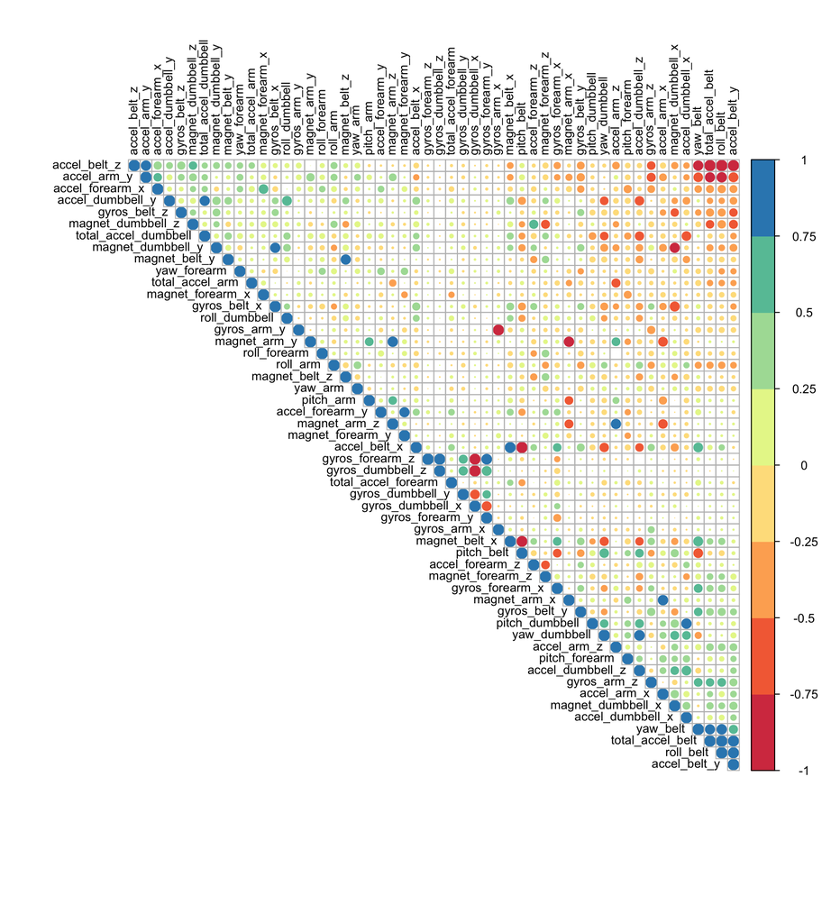

```r
# We use the is.numeric flag to make sure we don't accidentally correlated our factor 'classe' variable with anything as it's an outcome:
corrMatrix <- cor(na.omit(trainData[sapply(trainData, is.numeric)]))
plotitupson <- corrplot(corrMatrix, order = "FPC", method = "circle", sig.level = 0.01, insig = "blank", type = "upper", col=brewer.pal(n=8, name="Spectral"), tl.cex = 0.8, tl.col = rgb(0, 0, 0))
```

#### 01e -> Remove variables that are highly correlated with each other:

```r
# We're going to use 90% as a cutoff value:
removecor <- findCorrelation(corrMatrix, cutoff = .90, verbose = FALSE)
trainData <- trainData[,-removecor]
dim(trainData)
```

```
## [1] 19622    46
```

### At this point data is sufficiently cleaned for analysis!!! #Yeah!

## 02) Analysis with Cross Validation

*We’re going to split our large training set into a 70/30 split for cross validation. Because we have almost 20,000 total rows, this should give us enough data in the sub-test set to have confidence that our findings in the sub-training set actualy reflect reality and we aren’t just overfitting our model. ~6000 rows in the sub-test set feels like we can have confidence comparing the test and training sets.*

```r
# We split training into sub train and test groups for cross validation:
inTrain <- createDataPartition(y=trainData$classe, p=0.7, list=FALSE)
training <- trainData[inTrain,]
testing <- trainData[-inTrain,]
dim(training)
```

```
## [1] 13737    46
```

```r
dim(testing)
```

```
## [1] 5885   46
```

*Again, we made out sub-test test 30% of the original training size, with the 70% balance going to the new sub-training set*

#### 02b -> Decision Trees as EDA

```r
# Let's run a tree algorithm on our training set:
tree.training <- tree(classe~.,data=training)
summary(tree.training)
```

```
##
## Classification tree:
## tree(formula = classe ~ ., data = training)
## Variables actually used in tree construction:
##  [1] "pitch_forearm"     "magnet_belt_y"     "accel_forearm_z"
##  [4] "magnet_dumbbell_y" "roll_forearm"      "magnet_dumbbell_z"
##  [7] "pitch_belt"        "yaw_belt"          "accel_forearm_x"
## [10] "accel_dumbbell_y"  "magnet_belt_x"     "accel_dumbbell_z"
## [13] "magnet_forearm_y"  "magnet_arm_x"      "gyros_belt_z"
## Number of terminal nodes:  24
## Residual mean deviance:  1.567 = 21490 / 13710
## Misclassification error rate: 0.3016 = 4143 / 13737
```

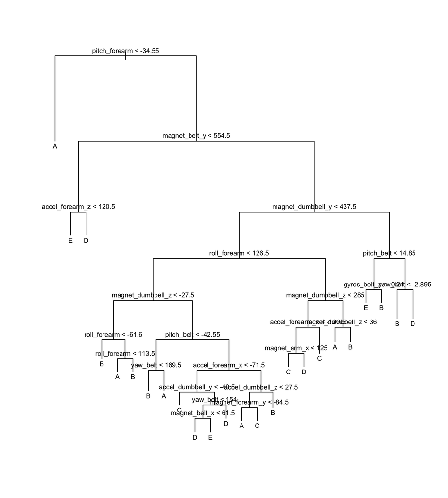

```r
plot(tree.training)
text(tree.training,pretty=0, cex =.8)
```

*This almost like using Exploratory Data Analysis for Machine Learning. Here we now see the ‘lay of the land’ of where all of our predictors sit in predicting the proper way (classe A) to do the exercise. It looks like **‘pitch_foream’** is the most important predictor.. but more on that later*